# 导入需要的库

```python
# import libraries
from pyspark.sql import SparkSession, Window
from pyspark.ml.feature import RegexTokenizer, VectorAssembler, Normalizer, StandardScaler
from pyspark.sql.functions import avg, col, concat, desc, explode, lit, min, max, count, split, udf, isnull, weekofyear
```

```python
from pyspark.ml import Pipeline
from pyspark.ml.classification import LogisticRegression,DecisionTreeClassifier,\
    LogisticRegressionModel, RandomForestClassifier,RandomForestClassificationModel

from pyspark.ml.evaluation import MulticlassClassificationEvaluator
from pyspark.mllib.evaluation import MulticlassMetrics

from pyspark.ml.feature import CountVectorizer, IDF, Normalizer, \
    PCA, RegexTokenizer, Tokenizer, StandardScaler, StopWordsRemover, \
    StringIndexer, VectorAssembler, MaxAbsScaler
from pyspark.ml.regression import LinearRegression
from pyspark.ml.clustering import KMeans
from pyspark.ml.tuning import CrossValidator, ParamGridBuilder
```

```python
from pyspark.sql.functions import udf
from pyspark.sql.types import StringType
from pyspark.sql.types import IntegerType, FloatType
from pyspark.sql.functions import desc
from pyspark.sql.functions import asc
from pyspark.sql.functions import sum as Fsum
```

```python
from time import time
import re
import numpy as np
import scipy
import pandas as pd
import datetime
import matplotlib.pyplot as plt
from pandas.plotting import scatter_matrix
import seaborn as sns
import random
%matplotlib inline
```

```python
spark = SparkSession.builder \
    .master("local") \
    .appName("Music App") \
    .getOrCreate()
stack_overflow_data = 'mini_sparkify_event_data.json'
df = spark.read.json(stack_overflow_data)
```

# 数据洞察和清洗

## 数据概览

```python
df.head()
```

```
Row(artist='Martha Tilston', auth='Logged In', firstName='Colin', gender='M', itemInSession=50, lastName='Freeman', length=277.89016, level='paid', location='Bakersfield, CA', method='PUT', page='NextSong', registration=1538173362000, sessionId=29, song='Rockpools', status=200, ts=1538352117000, use…
```

```python
df.count()
```

```
286500
```

```python
df.select("userId").dropDuplicates().count()
```

```
226
```

```python
df.printSchema()  #充分理解数据各个字段的含义，数据类型，大致分布，才可以进一步探索数据
```

```
root
 |-- artist: string (nullable = true)
 |-- auth: string (nullable = true)
 |-- firstName: string (nullable = true)
 |-- gender: string (nullable = true)
 |-- itemInSession: long (nullable = true)
 |-- lastName: string (nullable = true)
 |-- length: double (nullable = true)
 |-- level: string (nullable = true)
 |-- location: string (nullable = true)
 |-- method: string (nullable = true)
 |-- page: string (nullable = true)
 |-- registration: long (nullable = true)
 |-- sessionId: long (nullable = true)
 |-- song: string (nullable = true)
 |-- status: long (nullable = true)
 |-- ts: long (nullable = true)
 |-- userAgent: string (nullable = true)
 |-- userId: string (nullable = true)
```

```python
df.describe().show()
```

```
+-------+------------------+----------+---------+------+------------------+--------+-----------------+------+-----------------+------+-------+--------------------+-----------------+--------------------+------------------+--------------------+--------------------+-----------------+
|summary|            artist|      auth|firstName|gender|     itemInSession|lastName|           length| level|         location|method|   page|        registration|        sessionId|                song|            status|                  ts|           userAgent|           userId|
+-------+------------------+----------+---------+------+------------------+--------+-----------------+------+-----------------+------+-------+--------------------+-----------------+--------------------+------------------+--------------------+--------------------+-----------------+
|  count|            228108|    286500|   278154|278154|            286500|  278154|           228108|286500|           278154|286500| 286500|              278154|           286500|              228108|            286500|              286500|              278154|           286500|
|   mean| 551.0852017937219|      null|     null|  null|114.41421291448516|    null|249.1171819778458|  null|             null|  null|   null|1.535358834084427...|1041.526554973822|            Infinity|210.05459685863875|1.540956889810483...|                null|59682.02278593872|
| stddev|1217.7693079161374|      null|     null|  null|129.76726201140994|    null|99.23517921058361|  null|             null|  null|   null| 3.291321616327586E9|726.7762634630741|                 NaN| 31.50507848842214|1.5075439608226302E9|                null|109091.9499991047|
|    min|               !!!| Cancelled| Adelaida|     F|                 0|   Adams|          0.78322|  free|       Albany, OR|   GET|  About|       1521380675000|                1|ÃÂg ÃÂtti Gr...|               200|       1538352117000|"Mozilla/5.0 (Mac...|                 |
|    max| ÃÂlafur Arnalds|Logged Out|   Zyonna|     M|              1321|  Wright|       3024.66567|  paid|Winston-Salem, NC|   PUT|Upgrade|       1543247354000|             2474|ÃÂau hafa slopp...|               404|       1543799476000|Mozilla/5.0 (comp...|               99|
+-------+------------------+----------+---------+------+------------------+--------+-----------------+------+-----------------+------+-------+--------------------+-----------------+--------------------+------------------+--------------------+--------------------+-----------------+
```

## 过滤掉未注册用户

```python
df.select("userID").show()  #存在空值，说明有些客户没有登录
```

```
+------+
|userID|
+------+
|    30|
|     9|
|    30|
|     9|
|    30|
|     9|
|     9|
|    30|
|    30|
|    30|
|     9|
|     9|
|    30|
|     9|
|     9|
|    30|
|     9|
|    74|
|    30|
|     9|
+------+
only showing top 20 rows
```

```python
df.where(df.userId == "").show()
```

```
+------+----------+---------+------+-------------+--------+------+-----+--------+------+-----+------------+---------+----+------+-------------+---------+------+
|artist|      auth|firstName|gender|itemInSession|lastName|length|level|location|method| page|registration|sessionId|song|status|           ts|userAgent|userId|
+------+----------+---------+------+-------------+--------+------+-----+--------+------+-----+------------+---------+----+------+-------------+---------+------+
|  null|Logged Out|     null|  null|          100|    null|  null| free|    null|   GET| Home|        null|        8|null|   200|1538355745000|     null|      |
|  null|Logged Out|     null|  null|          101|    null|  null| free|    null|   GET| Help|        null|        8|null|   200|1538355807000|     null|      |
|  null|Logged Out|     null|  null|          102|    null|  null| free|    null|   GET| Home|        null|        8|null|   200|1538355841000|     null|      |
|  null|Logged Out|     null|  null|          103|    null|  null| free|    null|   PUT|Login|        null|        8|null|   307|1538355842000|     null|      |
|  null|Logged Out|     null|  null|            2|    null|  null| free|    null|   GET| Home|        null|      240|null|   200|1538356678000|     null|      |
|  null|Logged Out|     null|  null|            3|    null|  null| free|    null|   PUT|Login|        null|      240|null|   307|1538356679000|     null|      |
|  null|Logged Out|     null|  null|            0|    null|  null| free|    null|   PUT|Login|        null|      100|null|   307|1538358102000|     null|      |
|  null|Logged Out|     null|  null|            0|    null|  null| free|    null|   PUT|Login|        null|      241|null|   307|1538360117000|     null|      |
|  null|Logged Out|     null|  null|           14|    null|  null| free|    null|   GET| Home|        null|      187|null|   200|1538361527000|     null|      |
|  null|Logged Out|     null|  null|           15|    null|  null| free|    null|   PUT|Login|        null|      187|null|   307|1538361528000|     null|      |
|  null|Logged Out|     null|  null|           21|    null|  null| free|    null|   GET| Home|        null|      187|null|   200|1538362007000|     null|      |
|  null|Logged Out|     null|  null|           22|    null|  null| free|    null|   GET| Home|        null|      187|null|   200|1538362095000|     null|      |
|  null|Logged Out|     null|  null|           23|    null|  null| free|    null|   PUT|Login|        null|      187|null|   307|1538362096000|     null|      |
|  null|Logged Out|     null|  null|            0|    null|  null| free|    null|   GET| Home|        null|       27|null|   200|1538363488000|     null|      |
|  null|Logged Out|     null|  null|            1|    null|  null| free|    null|   GET|About|        null|       27|null|   200|1538363494000|     null|      |
|  null|Logged Out|     null|  null|            2|    null|  null| free|    null|   GET| Home|        null|       27|null|   200|1538363503000|     null|      |
|  null|Logged Out|     null|  null|           38|    null|  null| free|    null|   GET| Home|        null|      187|null|   200|1538364254000|     null|      |
|  null|Logged Out|     null|  null|           39|    null|  null| free|    null|   PUT|Login|        null|      187|null|   307|1538364255000|     null|      |
|  null|Logged Out|     null|  null|            0|    null|  null| free|    null|   GET| Home|        null|      257|null|   200|1538364750000|     null|      |
|  null|Logged Out|     null|  null|           47|    null|  null| free|    null|   GET| Home|        null|      100|null|   200|1538370681000|     null|      |
+------+----------+---------+------+-------------+--------+------+-----+--------+------+-----+------------+---------+----+------+-------------+---------+------+
only showing top 20 rows
```

```python
df = df.filter(col('userId') != '')
```

```python
df.count()
```

```
278154
```

```python
df.select("userId").dropDuplicates().count()
```

```
225
```

```python
df.select("artist").show()  #查看到歌曲、艺术家首字母均是大写
```

```
+--------------------+
|              artist|
+--------------------+
|      Martha Tilston|
|    Five Iron Frenzy|
|        Adam Lambert|
|              Enigma|
|           Daft Punk|
|The All-American ...|
|The Velvet Underg...|
|        Starflyer 59|
|                null|
|            Frumpies|
|        Britt Nicole|
|                null|
|Edward Sharpe & T...|
|               Tesla|
|                null|
|         Stan Mosley|
|Florence + The Ma...|
|   Tokyo Police Club|
|             Orishas|
|             Ratatat|
+--------------------+
only showing top 20 rows
```

## 转换时间字段

```python
#转换时间格式
get_time = udf(lambda x: datetime.datetime.fromtimestamp(x / 1000.0).strftime(
    "%Y-%m-%d %H:%M:%S"))
df = df.withColumn("time", get_time(df.ts))
```

```python
#便于查看小时、周几、几号的流失、非流失听歌频率的分布
get_hour = udf(lambda x: datetime.datetime.fromtimestamp(x / 1000.0).hour)
df = df.withColumn("hour", get_hour(df.ts))

get_weekday = udf(
    lambda x: datetime.datetime.fromtimestamp(x / 1000.0).strftime("%w"))
df = df.withColumn("weekday", get_weekday(df.ts))

get_day = udf(lambda x: datetime.datetime.fromtimestamp(x / 1000.0).day)
df = df.withColumn("day", get_day(df.ts))
```

```python
df.take(5)
```

```
[Row(artist='Martha Tilston', auth='Logged In', firstName='Colin', gender='M', itemInSession=50, lastName='Freeman', length=277.89016, level='paid', location='Bakersfield, CA', method='PUT', page='NextSong', registration=1538173362000, sessionId=29, song='Rockpools', status=200, ts=1538352117000, us…
 Row(artist='Five Iron Frenzy', auth='Logged In', firstName='Micah', gender='M', itemInSession=79, lastName='Long', length=236.09424, level='free', location='Boston-Cambridge-Newton, MA-NH', method='PUT', page='NextSong', registration=1538331630000, sessionId=8, song='Canada', status=200, ts=1538352…
 Row(artist='Adam Lambert', auth='Logged In', firstName='Colin', gender='M', itemInSession=51, lastName='Freeman', length=282.8273, level='paid', location='Bakersfield, CA', method='PUT', page='NextSong', registration=1538173362000, sessionId=29, song='Time For Miracles', status=200, ts=153835239400…
 Row(artist='Enigma', auth='Logged In', firstName='Micah', gender='M', itemInSession=80, lastName='Long', length=262.71302, level='free', location='Boston-Cambridge-Newton, MA-NH', method='PUT', page='NextSong', registration=1538331630000, sessionId=8, song='Knocking On Forbidden Doors', status=200,…
 Row(artist='Daft Punk', auth='Logged In', firstName='Colin', gender='M', itemInSession=52, lastName='Freeman', length=223.60771, level='paid', location='Bakersfield, CA', method='PUT', page='NextSong', registration=1538173362000, sessionId=29, song='Harder Better Faster Stronger', status=200, ts=15…
```

## 转换性别、级别为数值

```python
tran_gender = udf(lambda x: 1 if x == "M" else 0, IntegerType())
df = df.withColumn("gender", tran_gender("gender"))
tran_level = udf(lambda x: 1 if x == "paid" else 0, IntegerType())
df = df.withColumn("level", tran_level("level"))
```

# 数据探索

## 定义流失客户

```python
df.filter("page = 'Cancellation Confirmation'").show()  #查看流失用户，具体流失用户的详细日志
```

```
+------+---------+---------+------+-------------+---------+------+-----+--------------------+------+--------------------+-------------+---------+----+------+-------------+--------------------+------+-------------------+----+-------+---+
|artist|     auth|firstName|gender|itemInSession| lastName|length|level|            location|method|                page| registration|sessionId|song|status|           ts|           userAgent|userId|               time|hour|weekday|day|
+------+---------+---------+------+-------------+---------+------+-----+--------------------+------+--------------------+-------------+---------+----+------+-------------+--------------------+------+-------------------+----+-------+---+
|  null|Cancelled|   Adriel|     1|          104|  Mendoza|  null|    1|  Kansas City, MO-KS|   GET|Cancellation Conf...|1535623466000|      514|null|   200|1538943990000|"Mozilla/5.0 (Mac...|    18|2018-10-07 20:26:30|  20|      0|  7|
|  null|Cancelled|    Diego|     1|           56|    Mckee|  null|    1|Phoenix-Mesa-Scot...|   GET|Cancellation Conf...|1537167593000|      540|null|   200|1539033046000|"Mozilla/5.0 (iPh...|    32|2018-10-08 21:10:46|  21|      1|  8|
|  null|Cancelled|    Mason|     1|           10|     Hart|  null|    0|  Corpus Christi, TX|   GET|Cancellation Conf...|1533157139000|      174|null|   200|1539318918000|"Mozilla/5.0 (Mac...|   125|2018-10-12 04:35:18|   4|      5| 12|
|  null|Cancelled|Alexander|     1|          332|   Garcia|  null|    1|Indianapolis-Carm...|   GET|Cancellation Conf...|1536817381000|      508|null|   200|1539375441000|Mozilla/5.0 (Wind...|   105|2018-10-12 20:17:21|  20|      5| 12|
|  null|Cancelled|    Kayla|     0|          273|  Johnson|  null|    1|Philadelphia-Camd...|   GET|Cancellation Conf...|1538333829000|      797|null|   200|1539465584000|Mozilla/5.0 (Wind...|    17|2018-10-13 21:19:44|  21|      6| 13|
|  null|Cancelled|    Molly|     0|           29| Harrison|  null|    0|Virginia Beach-No...|   GET|Cancellation Conf...|1534255113000|      843|null|   200|1539588854000|"Mozilla/5.0 (Mac...|   143|2018-10-15 07:34:14|   7|      1| 15|
|  null|Cancelled|     Alex|     1|          145|    Hogan|  null|    1|Denver-Aurora-Lak...|   GET|Cancellation Conf...|1535066380000|      842|null|   200|1539729037000|Mozilla/5.0 (Wind...|   101|2018-10-16 22:30:37|  22|      2| 16|
|  null|Cancelled|    Davis|     1|           34|     Wang|  null|    1|           Flint, MI|   GET|Cancellation Conf...|1538289776000|      802|null|   200|1539736161000|"Mozilla/5.0 (Win...|   129|2018-10-17 00:29:21|   0|      3| 17|
|  null|Cancelled|  Nikolas|     1|          287|    Olsen|  null|    1|Oxnard-Thousand O...|   GET|Cancellation Conf...|1528403713000|      881|null|   200|1539759749000|Mozilla/5.0 (X11;...|   121|2018-10-17 07:02:29|   7|      3| 17|
|  null|Cancelled|    Ethan|     1|          176|  Johnson|  null|    1|Lexington-Fayette...|   GET|Cancellation Conf...|1538080987000|      934|null|   200|1539761972000|"Mozilla/5.0 (Win...|    51|2018-10-17 07:39:32|   7|      3| 17|
|  null|Cancelled|Christian|     1|          100| Robinson|  null|    1|       Quincy, IL-MO|   GET|Cancellation Conf...|1534942082000|     1092|null|   200|1540050556000|"Mozilla/5.0 (Win...|    87|2018-10-20 15:49:16|  15|      6| 20|
|  null|Cancelled|    Molly|     0|           43|Patterson|  null|    1|   Memphis, TN-MS-AR|   GET|Cancellation Conf...|1535498705000|     1029|null|   200|1540062068000|Mozilla/5.0 (X11;...|   122|2018-10-20 19:01:08|  19|      6| 20|
|  null|Cancelled|   Sophia|     0|           72|    Perry|  null|    1|Los Angeles-Long ...|   GET|Cancellation Conf...|1533885783000|     1072|null|   200|1540193374000|Mozilla/5.0 (Wind...|    12|2018-10-22 07:29:34|   7|      1| 22|
|  null|Cancelled|    Erick|     1|           48|   Brooks|  null|    1|           Selma, AL|   GET|Cancellation Conf...|1537956751000|     1112|null|   200|1540223006000|"Mozilla/5.0 (Win...|    58|2018-10-22 15:43:26|  15|      1| 22|
|  null|Cancelled|   Rachel|     0|           11|   Bailey|  null|    1|Albany-Schenectad...|   GET|Cancellation Conf...|1536102943000|     1059|null|   200|1540402387000|Mozilla/5.0 (Wind...|    73|2018-10-24 17:33:07|  17|      3| 24|
|  null|Cancelled|  Jeffery|     1|           46|  Wheeler|  null|    1|         Bozeman, MT|   GET|Cancellation Conf...|1533886191000|     1324|null|   200|1540875543000|"Mozilla/5.0 (Win...|     3|2018-10-30 04:59:03|   4|      2| 30|
|  null|Cancelled|   Sophia|     0|           18|      Key|  null|    1|Los Angeles-Long ...|   GET|Cancellation Conf...|1537679535000|     1383|null|   200|1541166424000|"Mozilla/5.0 (Mac...|   106|2018-11-02 13:47:04|  13|      5|  2|
|  null|Cancelled|    Piper|     0|            8|  Nielsen|  null|    1|New York-Newark-J...|   GET|Cancellation Conf...|1537699856000|     1583|null|   200|1541340091000|"Mozilla/5.0 (Mac...|   103|2018-11-04 14:01:31|  14|      0|  4|
|  null|Cancelled|   Teagan|     0|          306|  Roberts|  null|    1|New Philadelphia-...|   GET|Cancellation Conf...|1537634865000|     1519|null|   200|1541463632000|Mozilla/5.0 (Wind...|    28|2018-11-06 00:20:32|   0|      2|  6|
|  null|Cancelled|    Alexi|     0|           42|   Warren|  null|    1|Spokane-Spokane V...|   GET|Cancellation Conf...|1532482662000|     1819|null|   200|1542051608000|Mozilla/5.0 (Wind...|    54|2018-11-12 19:40:08|  19|      1| 12|
+------+---------+---------+------+-------------+---------+------+-----+--------------------+------+--------------------+-------------+---------+----+------+-------------+--------------------+------+-------------------+----+-------+---+
only showing top 20 rows
```

```python
df.select([
    "userId", "firstname", "page", "level", "song", "sessionId",
    "itemInSession", "day"
]).where(df.userId == "28").collect()[-100:]
```

```
[Row(userId='28', firstname='Teagan', page='NextSong', level=1, song='Songs That Make A Difference', sessionId=1519, itemInSession=205, day='5'),
 Row(userId='28', firstname='Teagan', page='Thumbs Down', level=1, song=None, sessionId=1519, itemInSession=206, day='5'),
 Row(userId='28', firstname='Teagan', page='NextSong', level=1, song='Pages In Blood', sessionId=1519, itemInSession=207, day='5'),
 Row(userId='28', firstname='Teagan', page='NextSong', level=1, song='Capitol City', sessionId=1519, itemInSession=208, day='5'),
 Row(userId='28', firstname='Teagan', page='NextSong', level=1, song='Dressed To Digress', sessionId=1519, itemInSession=209, day='5'),
 Row(userId='28', firstname='Teagan', page='Thumbs Down', level=1, song=None, sessionId=1519, itemInSession=210, day='5'),
 Row(userId='28', firstname='Teagan', page='NextSong', level=1, song='Agua', sessionId=1519, itemInSession=211, day='5'),
 Row(userId='28', firstname='Teagan', page='NextSong', level=1, song='Bohemian Forest', sessionId=1519, itemInSession=212, day='5'),
 Row(userId='28', firstname='Teagan', page='NextSong', level=1, song='Not Exactly', sessionId=1519, itemInSession=213, day='5'),
 Row(userId='28', firstname='Teagan', page='NextSong', level=1, song='Me And You Blues', sessionId=1519, itemInSession=214, day='5'),
 Row(userId='28', firstname='Teagan', page='NextSong', level=1, song='By Your Side', sessionId=1519, itemInSession=215, day='5'),
 Row(userId='28', firstname='Teagan', page='NextSong', level=1, song='Tears Of The Dragon', sessionId=1519, itemInSession=216, day='5'),
 Row(userId='28', firstname='Teagan', page='Thumbs Up', level=1, song=None, sessionId=1519, itemInSession=217, day='5'),
 Row(userId='28', firstname='Teagan', page='NextSong', level=1, song='El Salvador', sessionId=1519, itemInSession=218, day='5'),
 Row(userId='28', firstname='Teagan', page='NextSong', level=1, song='Volcan', sessionId=1519, itemInSession=219, day='5'),
 Row(userId='28', firstname='Teagan', page='NextSong', level=1, song='A Dustland Fairytale', sessionId=1519, itemInSession=220, day='5'),
 Row(userId='28', firstname='Teagan', page='NextSong', level=1, song='Tulinesangala', sessionId=1519, itemInSession=221, day='5'),
 Row(userId='28', firstname='Teagan', page='NextSong', level=1, song='So Jersey', sessionId=1519, itemInSession=222, day='5'),
 Row(userId='28', firstname='Teagan', page='NextSong', level=1, song='Sala De RecepÃ\x83Â§Ã\x83Â£o', sessionId=1519, itemInSession=223, day='5'),
 Row(userId='28', firstname='Teagan', page='NextSong', level=1, song="You Know You're Right", sessionId=1519, itemInSession=224, day='5'),
 Row(userId='28', firstname='Teagan', page='NextSong', level=1, song='Some Swedish Trees', sessionId=1519, itemInSession=225, day='5'),
 Row(userId='28', firstname='Teagan', page='NextSong', level=1, song='Bewildered', sessionId=1519, itemInSession=226, day='5'),
 Row(userId='28', firstname='Teagan', page='NextSong', level=1, song='Tudo De Voce', sessionId=1519, itemInSession=227, day='5'),
 Row(userId='28', firstname='Teagan', page='NextSong', level=1, song='The Cross [Live Audio]', sessionId=1519, itemInSession=228, day='5'),
 Row(userId='28', firstname='Teagan', page='NextSong', level=1, song='Peculiar', sessionId=1519, itemInSession=229, day='5'),
 Row(userId='28', firstname='Teagan', page='NextSong', level=1, song='Berlin', sessionId=1519, itemInSession=230, day='5'),
 Row(userId='28', firstname='Teagan', page='NextSong', level=1, song='Walls Of Huntsville', sessionId=1519, itemInSession=231, day='5'),
 Row(userId='28', firstname='Teagan', page='Thumbs Up', level=1, song=None, sessionId=1519, itemInSession=232, day='5'),
 Row(userId='28', firstname='Teagan', page='NextSong', level=1, song='Prefab', sessionId=1519, itemInSession=233, day='5'),
 Row(userId='28', firstname='Teagan', page='NextSong', level=1, song='The Life', sessionId=1519, itemInSession=234, day='5'),
 Row(userId='28', firstname='Teagan', page='NextSong', level=1, song='Gears', sessionId=1519, itemInSession=235, day='5'),
 Row(userId='28', firstname='Teagan', page='Downgrade', level=1, song=None, sessionId=1519, itemInSession=236, day='5'),
 Row(userId='28', firstname='Teagan', page='NextSong', level=1, song='Habalim', sessionId=1519, itemInSession=237, day='5'),
 Row(userId='28', firstname='Teagan', page='NextSong', level=1, song='Too Young', sessionId=1519, itemInSession=238, day='5'),
 Row(userId='28', firstname='Teagan', page='Home', level=1, song=None, sessionId=1519, itemInSession=239, day='5'),
 Row(userId='28', firstname='Teagan', page='NextSong', level=1, song='Blood Bank', sessionId=1519, itemInSession=240, day='5'),
 Row(userId='28', firstname='Teagan', page='NextSong', level=1, song='Revelry', sessionId=1519, itemInSession=241, day='5'),
 Row(userId='28', firstname='Teagan', page='NextSong', level=1, song='Take A Walk Around The Table', sessionId=1519, itemInSession=242, day='5'),
 Row(userId='28', firstname='Teagan', page='NextSong', level=1, song='Picture', sessionId=1519, itemInSession=243, day='5'),
 Row(userId='28', firstname='Teagan', page='Thumbs Up', level=1, song=None, sessionId=1519, itemInSession=244, day='5'),
```

[output cut: 45 more lines]

```
 Row(userId='28', firstname='Teagan', page='NextSong', level=1, song='Love Of My Life (1993 Digital Remaster)', sessionId=1519, itemInSession=292, day='5'),
 Row(userId='28', firstname='Teagan', page='NextSong', level=1, song='Home', sessionId=1519, itemInSession=293, day='5'),
 Row(userId='28', firstname='Teagan', page='NextSong', level=1, song="I Keep Going Back To Joe's", sessionId=1519, itemInSession=294, day='5'),
 Row(userId='28', firstname='Teagan', page='NextSong', level=1, song='Le Million', sessionId=1519, itemInSession=295, day='5'),
 Row(userId='28', firstname='Teagan', page='NextSong', level=1, song='Free Style (feat. Kevo_ Mussilini & Lyrical 187)', sessionId=1519, itemInSession=296, day='6'),
 Row(userId='28', firstname='Teagan', page='NextSong', level=1, song='Drive Slow', sessionId=1519, itemInSession=297, day='6'),
 Row(userId='28', firstname='Teagan', page='NextSong', level=1, song='Stupid Girl', sessionId=1519, itemInSession=298, day='6'),
 Row(userId='28', firstname='Teagan', page='NextSong', level=1, song='Abstract Art (feat. NO)', sessionId=1519, itemInSession=299, day='6'),
 Row(userId='28', firstname='Teagan', page='NextSong', level=1, song='Como Duele (Album)', sessionId=1519, itemInSession=300, day='6'),
 Row(userId='28', firstname='Teagan', page='Home', level=1, song=None, sessionId=1519, itemInSession=301, day='6'),
 Row(userId='28', firstname='Teagan', page='NextSong', level=1, song='Back In The Day', sessionId=1519, itemInSession=302, day='6'),
 Row(userId='28', firstname='Teagan', page='Downgrade', level=1, song=None, sessionId=1519, itemInSession=303, day='6'),
 Row(userId='28', firstname='Teagan', page='Downgrade', level=1, song=None, sessionId=1519, itemInSession=304, day='6'),
 Row(userId='28', firstname='Teagan', page='Cancel', level=1, song=None, sessionId=1519, itemInSession=305, day='6'),
 Row(userId='28', firstname='Teagan', page='Cancellation Confirmation', level=1, song=None, sessionId=1519, itemInSession=306, day='6')]
```

```python
churn_users = df.filter(
    df.page == "Cancellation Confirmation").select("userId").dropDuplicates()
churn_users_list = [(row['userId']) for row in churn_users.collect()]
```

```python
churn_users_list
```

```
['125',
 '51',
 '54',
 '100014',
 '101',
 '29',
 '100021',
 '87',
 '73',
 '3',
 '28',
 '100022',
 '100025',
 '300007',
 '100006',
 '18',
 '70',
 '100005',
 '17',
 '100007',
 '300001',
 '100009',
 '100015',
 '200024',
 '100003',
 '103',
 '100024',
 '53',
 '122',
 '200017',
 '58',
 '100011',
 '100019',
 '100012',
 '200018',
 '200016',
 '200020',
 '106',
 '143',
 '32',
 '200001',
 '105',
 '200011',
 '100023',
 '100013',
 '100017',
 '121',
 '12',
 '200015',
 '129',
 '200021',
 '100001']
```

```python
# 创建Churn列，用来标记后期证实流失的客户
flag_CancellationConfirmation_event = udf(
    lambda x: 1 if x in churn_users_list else 0, IntegerType())
df = df.withColumn("Churn", flag_CancellationConfirmation_event("userId"))

df.take(5)
```

```
[Row(artist='Martha Tilston', auth='Logged In', firstName='Colin', gender=1, itemInSession=50, lastName='Freeman', length=277.89016, level=1, location='Bakersfield, CA', method='PUT', page='NextSong', registration=1538173362000, sessionId=29, song='Rockpools', status=200, ts=1538352117000, userAgent…
 Row(artist='Five Iron Frenzy', auth='Logged In', firstName='Micah', gender=1, itemInSession=79, lastName='Long', length=236.09424, level=0, location='Boston-Cambridge-Newton, MA-NH', method='PUT', page='NextSong', registration=1538331630000, sessionId=8, song='Canada', status=200, ts=1538352180000,…
 Row(artist='Adam Lambert', auth='Logged In', firstName='Colin', gender=1, itemInSession=51, lastName='Freeman', length=282.8273, level=1, location='Bakersfield, CA', method='PUT', page='NextSong', registration=1538173362000, sessionId=29, song='Time For Miracles', status=200, ts=1538352394000, user…
 Row(artist='Enigma', auth='Logged In', firstName='Micah', gender=1, itemInSession=80, lastName='Long', length=262.71302, level=0, location='Boston-Cambridge-Newton, MA-NH', method='PUT', page='NextSong', registration=1538331630000, sessionId=8, song='Knocking On Forbidden Doors', status=200, ts=153…
 Row(artist='Daft Punk', auth='Logged In', firstName='Colin', gender=1, itemInSession=52, lastName='Freeman', length=223.60771, level=1, location='Bakersfield, CA', method='PUT', page='NextSong', registration=1538173362000, sessionId=29, song='Harder Better Faster Stronger', status=200, ts=153835267…
```

```python
df.select("Churn").show(100)  #大部分是没有取消服务的
```

```
+-----+
|Churn|
+-----+
|    0|
|    0|
|    0|
|    0|
|    0|
|    0|
|    0|
|    0|
|    0|
|    0|
|    0|
|    0|
|    0|
|    0|
|    0|
|    0|
|    0|
|    0|
|    0|
|    0|
|    0|
|    0|
|    1|
|    0|
|    0|
|    0|
|    1|
|    0|
|    0|
|    0|
|    1|
|    0|
|    0|
|    0|
|    1|
|    1|
|    0|
```

[output cut: 50 more lines]

```
|    0|
|    0|
|    0|
|    0|
|    0|
|    0|
|    0|
|    0|
|    0|
|    0|
|    0|
|    0|
|    0|
+-----+
only showing top 100 rows
```

```python
df.groupby("Churn").count().show()
```

```
+-----+------+
|Churn| count|
+-----+------+
|    1| 44864|
|    0|233290|
+-----+------+
```

```python
df.describe("itemInSession").show()
```

```
+-------+------------------+
|summary|     itemInSession|
+-------+------------------+
|  count|            278154|
|   mean|114.89918174824018|
| stddev|  129.851729399489|
|    min|                 0|
|    max|              1321|
+-------+------------------+
```

## 查看用户关键行为：升级、降级

```python
df.select(["userId", "page", "sessionId"
           ]).where(df.page == "Submit Downgrade").sort(["userId"]).collect()
```

```
[Row(userId='100', page='Submit Downgrade', sessionId=1590),
 Row(userId='100004', page='Submit Downgrade', sessionId=112),
 Row(userId='100004', page='Submit Downgrade', sessionId=147),
 Row(userId='100008', page='Submit Downgrade', sessionId=132),
 Row(userId='100009', page='Submit Downgrade', sessionId=126),
 Row(userId='100012', page='Submit Downgrade', sessionId=94),
 Row(userId='100015', page='Submit Downgrade', sessionId=121),
 Row(userId='100016', page='Submit Downgrade', sessionId=190),
 Row(userId='100018', page='Submit Downgrade', sessionId=67),
 Row(userId='100018', page='Submit Downgrade', sessionId=202),
 Row(userId='100025', page='Submit Downgrade', sessionId=123),
 Row(userId='103', page='Submit Downgrade', sessionId=865),
 Row(userId='109', page='Submit Downgrade', sessionId=1705),
 Row(userId='11', page='Submit Downgrade', sessionId=487),
 Row(userId='12', page='Submit Downgrade', sessionId=632),
 Row(userId='13', page='Submit Downgrade', sessionId=1695),
 Row(userId='13', page='Submit Downgrade', sessionId=1695),
 Row(userId='131', page='Submit Downgrade', sessionId=249),
 Row(userId='131', page='Submit Downgrade', sessionId=2041),
 Row(userId='140', page='Submit Downgrade', sessionId=753),
 Row(userId='140', page='Submit Downgrade', sessionId=1643),
 Row(userId='140', page='Submit Downgrade', sessionId=1918),
 Row(userId='141', page='Submit Downgrade', sessionId=479),
 Row(userId='20', page='Submit Downgrade', sessionId=378),
 Row(userId='20', page='Submit Downgrade', sessionId=1875),
 Row(userId='200003', page='Submit Downgrade', sessionId=28),
 Row(userId='200003', page='Submit Downgrade', sessionId=283),
 Row(userId='200009', page='Submit Downgrade', sessionId=251),
 Row(userId='200011', page='Submit Downgrade', sessionId=238),
 Row(userId='200019', page='Submit Downgrade', sessionId=148),
 Row(userId='200020', page='Submit Downgrade', sessionId=222),
 Row(userId='200023', page='Submit Downgrade', sessionId=69),
 Row(userId='200023', page='Submit Downgrade', sessionId=295),
 Row(userId='200025', page='Submit Downgrade', sessionId=115),
 Row(userId='24', page='Submit Downgrade', sessionId=1317),
 Row(userId='25', page='Submit Downgrade', sessionId=1718),
 Row(userId='30', page='Submit Downgrade', sessionId=532),
 Row(userId='300002', page='Submit Downgrade', sessionId=220),
 Row(userId='300004', page='Submit Downgrade', sessionId=267),
 Row(userId='300011', page='Submit Downgrade', sessionId=362),
```

[output cut: 8 more lines]

```
 Row(userId='39', page='Submit Downgrade', sessionId=1985),
 Row(userId='49', page='Submit Downgrade', sessionId=1744),
 Row(userId='54', page='Submit Downgrade', sessionId=859),
 Row(userId='59', page='Submit Downgrade', sessionId=510),
 Row(userId='61', page='Submit Downgrade', sessionId=529),
 Row(userId='61', page='Submit Downgrade', sessionId=2345),
 Row(userId='74', page='Submit Downgrade', sessionId=1101),
 Row(userId='77', page='Submit Downgrade', sessionId=688),
 Row(userId='81', page='Submit Downgrade', sessionId=725),
 Row(userId='85', page='Submit Downgrade', sessionId=734),
 Row(userId='85', page='Submit Downgrade', sessionId=1183),
 Row(userId='9', page='Submit Downgrade', sessionId=1276),
 Row(userId='92', page='Submit Downgrade', sessionId=2125),
 Row(userId='95', page='Submit Downgrade', sessionId=826),
 Row(userId='96', page='Submit Downgrade', sessionId=1689)]
```

```python
df.select(["userId", "page", "sessionId"
           ]).where(df.page == "Submit Upgrade").sort(["userId"]).collect()
```

```
[Row(userId='100', page='Submit Upgrade', sessionId=1899),
 Row(userId='100004', page='Submit Upgrade', sessionId=108),
 Row(userId='100004', page='Submit Upgrade', sessionId=112),
 Row(userId='100004', page='Submit Upgrade', sessionId=208),
 Row(userId='100009', page='Submit Upgrade', sessionId=85),
 Row(userId='100012', page='Submit Upgrade', sessionId=59),
 Row(userId='100013', page='Submit Upgrade', sessionId=62),
 Row(userId='100015', page='Submit Upgrade', sessionId=79),
 Row(userId='100015', page='Submit Upgrade', sessionId=162),
 Row(userId='100018', page='Submit Upgrade', sessionId=67),
 Row(userId='100018', page='Submit Upgrade', sessionId=114),
 Row(userId='100023', page='Submit Upgrade', sessionId=61),
 Row(userId='101', page='Submit Upgrade', sessionId=312),
 Row(userId='103', page='Submit Upgrade', sessionId=865),
 Row(userId='103', page='Submit Upgrade', sessionId=916),
 Row(userId='104', page='Submit Upgrade', sessionId=1103),
 Row(userId='105', page='Submit Upgrade', sessionId=104),
 Row(userId='106', page='Submit Upgrade', sessionId=429),
 Row(userId='108', page='Submit Upgrade', sessionId=1228),
 Row(userId='109', page='Submit Upgrade', sessionId=108),
 Row(userId='11', page='Submit Upgrade', sessionId=487),
 Row(userId='11', page='Submit Upgrade', sessionId=1824),
 Row(userId='111', page='Submit Upgrade', sessionId=1416),
 Row(userId='113', page='Submit Upgrade', sessionId=366),
 Row(userId='114', page='Submit Upgrade', sessionId=1013),
 Row(userId='115', page='Submit Upgrade', sessionId=316),
 Row(userId='118', page='Submit Upgrade', sessionId=601),
 Row(userId='12', page='Submit Upgrade', sessionId=379),
 Row(userId='12', page='Submit Upgrade', sessionId=910),
 Row(userId='121', page='Submit Upgrade', sessionId=719),
 Row(userId='122', page='Submit Upgrade', sessionId=1029),
 Row(userId='126', page='Submit Upgrade', sessionId=988),
 Row(userId='128', page='Submit Upgrade', sessionId=834),
 Row(userId='129', page='Submit Upgrade', sessionId=536),
 Row(userId='13', page='Submit Upgrade', sessionId=1524),
 Row(userId='13', page='Submit Upgrade', sessionId=1695),
 Row(userId='131', page='Submit Upgrade', sessionId=249),
 Row(userId='132', page='Submit Upgrade', sessionId=131),
 Row(userId='136', page='Submit Upgrade', sessionId=855),
 Row(userId='137', page='Submit Upgrade', sessionId=408),
```

[output cut: 104 more lines]

```
 Row(userId='85', page='Submit Upgrade', sessionId=1098),
 Row(userId='85', page='Submit Upgrade', sessionId=1303),
 Row(userId='86', page='Submit Upgrade', sessionId=1855),
 Row(userId='87', page='Submit Upgrade', sessionId=1036),
 Row(userId='88', page='Submit Upgrade', sessionId=1065),
 Row(userId='89', page='Submit Upgrade', sessionId=636),
 Row(userId='9', page='Submit Upgrade', sessionId=367),
 Row(userId='9', page='Submit Upgrade', sessionId=1347),
 Row(userId='91', page='Submit Upgrade', sessionId=693),
 Row(userId='92', page='Submit Upgrade', sessionId=501),
 Row(userId='93', page='Submit Upgrade', sessionId=2329),
 Row(userId='96', page='Submit Upgrade', sessionId=2300),
 Row(userId='97', page='Submit Upgrade', sessionId=1359),
 Row(userId='98', page='Submit Upgrade', sessionId=1139),
 Row(userId='99', page='Submit Upgrade', sessionId=699)]
```

## 观察用户使用最多的页面

```python
df.groupBy('Page').count().sort("count", ascending=False).show()
```

```
+--------------------+------+
|                Page| count|
+--------------------+------+
|            NextSong|228108|
|           Thumbs Up| 12551|
|                Home| 10082|
|     Add to Playlist|  6526|
|          Add Friend|  4277|
|         Roll Advert|  3933|
|              Logout|  3226|
|         Thumbs Down|  2546|
|           Downgrade|  2055|
|            Settings|  1514|
|                Help|  1454|
|             Upgrade|   499|
|               About|   495|
|       Save Settings|   310|
|               Error|   252|
|      Submit Upgrade|   159|
|    Submit Downgrade|    63|
|              Cancel|    52|
|Cancellation Conf...|    52|
+--------------------+------+
```

## 用户流失在不同性别的分布

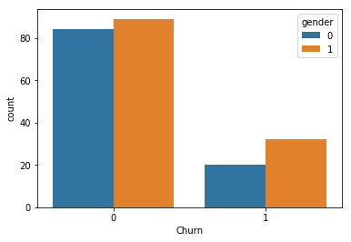

```python
df_pd = df.dropDuplicates(["userId", "gender"
                           ]).groupby(["Churn", "gender"
                                       ]).count().sort("Churn").toPandas()
sns.barplot(x='Churn', y='count', hue='gender', data=df_pd)
#1 male,paid 1,Churn 1
```

## 用户流失在不同会员等级的分布

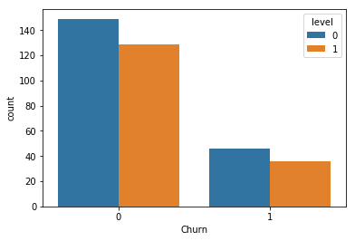

```python
df_pd = df.dropDuplicates(["userId", "level"
                           ]).groupby(["Churn", "level"
                                       ]).count().sort("Churn").toPandas()
sns.barplot(x='Churn', y='count', hue='level', data=df_pd)
```

```python
df.groupBy(['churn', 'userAgent']).count().where(df['churn'] == 0).sort(
    col('count').desc()).show(5)
df.groupBy(['churn', 'userAgent']).count().where(df['churn'] == 1).sort(
    col('count').desc()).show(5)
```

[output not shown]

## 用户流失最多的地区

```python
df.select("userId", "Churn", "location").dropDuplicates().groupby(
    ["location", "Churn"]).count().sort(["Churn", "count"],
                                        ascending=False).show(10)
```

```
+--------------------+-----+-----+
|            location|Churn|count|
+--------------------+-----+-----+
|New York-Newark-J...|    1|    5|
|Los Angeles-Long ...|    1|    3|
|Philadelphia-Camd...|    1|    2|
|Phoenix-Mesa-Scot...|    1|    2|
|Spokane-Spokane V...|    1|    2|
|Miami-Fort Lauder...|    1|    2|
|           Flint, MI|    1|    2|
|         Jackson, MS|    1|    2|
|Greenville-Anders...|    1|    1|
|Indianapolis-Carm...|    1|    1|
+--------------------+-----+-----+
only showing top 10 rows
```

## 流失用户的每次登陆页面操作数

```python
df.groupBy([
    'userId', 'churn'
]).avg('itemInSession').groupBy('churn').avg('avg(itemInSession)').show()
```

```
+-----+-----------------------+
|churn|avg(avg(itemInSession))|
+-----+-----------------------+
|    1|      72.39591226205863|
|    0|      89.13463393625388|
+-----+-----------------------+
```

## 用户在线时段观察

```python
def plot_cnt_by_churn(time):
    """
    此函数用来绘制频率分布的直方图
    """
    df_pd = df.filter(df.page == "NextSong").groupby(
        "churn", time).count().orderBy(df[time].cast("float")).toPandas()
    df_pd[time] = pd.to_numeric(df_pd[time])
    df_pd[df_pd.churn == 0].plot.bar(x=time,
                                     y='count',
                                     color='burlywood',
                                     label='Not churn')
    df_pd[df_pd.churn == 1].plot.bar(x=time,
                                     y='count',
                                     color='lightseagreen',
                                     label='Churn')
```

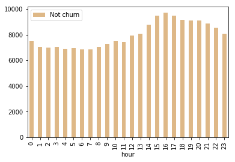

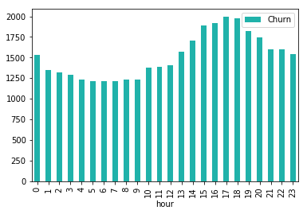

```python
plot_cnt_by_churn("hour")
```

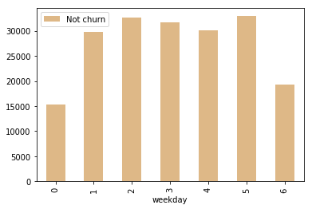

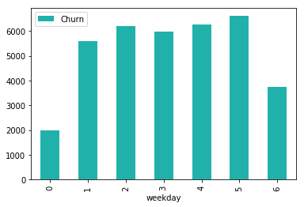

```python
plot_cnt_by_churn("weekday")
```

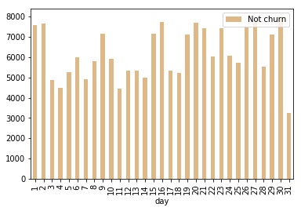

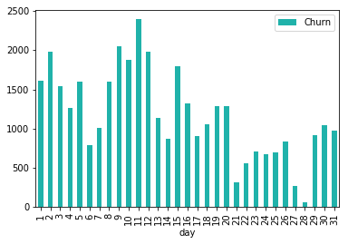

```python
plot_cnt_by_churn("day")
```

# 特征工程

## 每个用户相关关键页面操作累计和

```python
# for thepage in ["Help","Error","Upgrade","SubmitUpgrade","Downgrade","SubmitDowngrade","Cancel"]:
df_Help=df.select('userID','page')\
.where(df.page == 'Help')\
.groupBy('userID')\
.agg({'page':'count'})\
.withColumnRenamed('count(page)', 'num_Help')

df_Error=df.select('userID','page')\
.where(df.page == 'Error')\
.groupBy('userID')\
.agg({'page':'count'})\
.withColumnRenamed('count(page)', 'num_Error')

df_Upgrade=df.select('userID','page')\
.where(df.page == 'Upgrade')\
.groupBy('userID')\
.agg({'page':'count'})\
.withColumnRenamed('count(page)', 'num_Upgrade')

df_SubmitUpgrade=df.select('userID','page')\
.where(df.page == 'Submit Upgrade')\
.groupBy('userID')\
.agg({'page':'count'})\
.withColumnRenamed('count(page)', 'num_SubmitUpgrade')

df_Downgrade=df.select('userID','page')\
.where(df.page == 'Downgrade')\
.groupBy('userID')\
.agg({'page':'count'})\
.withColumnRenamed('count(page)', 'num_Downgrade')

df_SubmitDowngrade=df.select('userID','page')\
.where(df.page == 'Submit Downgrade')\
.groupBy('userID')\
.agg({'page':'count'})\
.withColumnRenamed('count(page)', 'SubmitDowngrade')
```

```python
df_SubmitDowngrade.show()
```

```
+------+---------------+
|userID|SubmitDowngrade|
+------+---------------+
|    54|              1|
|    11|              1|
|    30|              1|
|    59|              1|
|    85|              2|
|    35|              2|
|100008|              1|
|100025|              1|
|300002|              1|
|    96|              1|
|   100|              1|
|    61|              2|
|   131|              2|
|   140|              3|
|300004|              1|
|300015|              1|
|    77|              1|
|100009|              1|
|300011|              1|
|100004|              2|
+------+---------------+
only showing top 20 rows
```

## 用户累计参与度

```python
df_Add_to_Playlist=df.select('userID','page')\
.where(df.page == 'Add to Playlist')\
.groupBy('userID')\
.agg({'page':'count'})\
.withColumnRenamed('count(page)', 'num_Add_to_Playlist')

df_Add_Friend=df.select('userID','page')\
.where(df.page == 'Add Friend')\
.groupBy('userID')\
.agg({'page':'count'})\
.withColumnRenamed('count(page)', 'num_Add_Friend')
```

```python
df_Add_Friend.show()
```

```
+------+--------------+
|userID|num_Add_Friend|
+------+--------------+
|100010|             4|
|200002|             4|
|    51|            28|
|   124|            74|
|     7|             1|
|    54|            33|
|    15|            31|
|   155|            11|
|   132|            41|
|   154|             3|
|100014|             6|
|   101|            29|
|    11|             6|
|   138|            41|
|300017|            63|
|    29|            47|
|    69|            12|
|100021|             7|
|    42|            52|
|   112|             7|
+------+--------------+
only showing top 20 rows
```

```python
df_Add_to_Playlist.show()
```

```
+------+-------------------+
|userID|num_Add_to_Playlist|
+------+-------------------+
|100010|                  7|
|200002|                  8|
|    51|                 52|
|   124|                118|
|     7|                  5|
|    15|                 59|
|    54|                 72|
|   155|                 24|
|   132|                 38|
|   154|                  1|
|100014|                  7|
|   101|                 61|
|    11|                 20|
|   138|                 67|
|300017|                113|
|    29|                 89|
|    69|                 33|
|100021|                  7|
|    42|                104|
|   112|                  7|
+------+-------------------+
only showing top 20 rows
```

## 每个SessionId的统计指标

```python
user_session_time = df.select("userId", "sessionId", "ts").groupby(
    "userId", "sessionId").agg(
        ((max(df.ts) - min(df.ts)) / (1000 * 60)).alias("sessionTime"))
user_session_time_stat = user_session_time.groupby("userId").agg(
    avg(user_session_time.sessionTime).alias("avgSessionTime"),
    min(user_session_time.sessionTime).alias("minSessionTime"),
    max(user_session_time.sessionTime).alias("maxSessionTime")).sort("userId")
```

```python
user_session_time_stat.show()
```

```
+------+------------------+-------------------+------------------+
|userId|    avgSessionTime|     minSessionTime|    maxSessionTime|
+------+------------------+-------------------+------------------+
|    10|459.74722222222226|  91.41666666666667|1547.9166666666667|
|   100| 316.5190476190476|                0.0|1019.5833333333334|
|100001|148.15833333333333|               63.0|215.28333333333333|
|100002|201.18333333333334|                0.0| 730.4666666666667|
|100003| 99.11666666666667|  3.216666666666667|195.01666666666668|
|100004|185.98650793650793|                0.0| 940.2166666666667|
|100005|120.18666666666668|                0.0|209.21666666666667|
|100006| 93.43333333333334|  93.43333333333334| 93.43333333333334|
|100007|189.41111111111113|                8.9| 675.6333333333333|
|100008| 528.2527777777779|              57.05|            2024.4|
|100009|211.96166666666667|  4.516666666666667| 666.3333333333334|
|100010|154.48333333333332|              22.55|             323.0|
|100011| 44.38333333333333|  44.38333333333333| 44.38333333333333|
|100012|271.43809523809523|                0.0| 729.4166666666666|
|100013|329.99880952380954|                0.0| 858.8166666666667|
|100014| 184.8138888888889|               3.45|            281.75|
|100015|278.59444444444443| 1.4833333333333334| 570.9333333333333|
|100016|265.40416666666664|               53.1|1049.4833333333333|
|100017|199.26666666666668| 199.26666666666668|199.26666666666668|
|100018|193.18730158730162|0.03333333333333333| 940.1666666666666|
+------+------------------+-------------------+------------------+
only showing top 20 rows
```

```python
user_session_song = df.select("userId", "sessionId", "song",
                              "page").filter(df.page == "NextSong").groupby(
                                  "userId", "sessionId").agg(
                                      count(df.song).alias("sessionSong"))
user_session_song_stat = user_session_song.groupby("userId").agg(
    avg(user_session_song.sessionSong).alias("avgSessionSong")).sort("userId")
```

```python
user_session_song_stat.show()
```

```
+------+------------------+
|userId|    avgSessionSong|
+------+------------------+
|    10|112.16666666666667|
|   100| 78.88235294117646|
|100001|             33.25|
|100002|             48.75|
|100003|              25.5|
|100004|              47.1|
|100005|              38.5|
|100006|              26.0|
|100007|              47.0|
|100008|128.66666666666666|
|100009|              51.8|
|100010|39.285714285714285|
|100011|              11.0|
|100012| 79.33333333333333|
|100013|              87.0|
|100014|42.833333333333336|
|100015| 66.66666666666667|
|100016|             66.25|
|100017|              52.0|
|100018|              50.1|
+------+------------------+
only showing top 20 rows
```

```python
user_session_Thumbs_Up = df.select(
    "userId", "sessionId", "page").filter(df.page == "Thumbs Up").groupby(
        "userId", "sessionId").agg(count(df.page).alias("sessionThumbs_Up"))
user_session_Thumbs_Up_stat = user_session_Thumbs_Up.groupby("userId").agg(
    avg(user_session_Thumbs_Up.sessionThumbs_Up).alias(
        "avgSessionThumbs_Up")).sort("userId")
```

```python
user_session_Thumbs_Up_stat.show()
```

```
+------+-------------------+
|userId|avgSessionThumbs_Up|
+------+-------------------+
|    10|  6.166666666666667|
|   100|  4.933333333333334|
|100001| 2.6666666666666665|
|100002|                2.5|
|100003|                3.0|
|100004| 2.6923076923076925|
|100005| 2.3333333333333335|
|100006|                2.0|
|100007| 3.1666666666666665|
|100008|                7.4|
|100009|              2.875|
|100010| 2.8333333333333335|
|100012|                3.6|
|100013| 3.5454545454545454|
|100014|                3.4|
|100015|                3.5|
|100016| 3.5714285714285716|
|100017|                2.0|
|100018| 3.5384615384615383|
|100019|                1.0|
+------+-------------------+
only showing top 20 rows
```

```python
user_session_Thumbs_Down = df.select(
    "userId", "sessionId", "page").filter(df.page == "Thumbs Down").groupby(
        "userId", "sessionId").agg(count(df.page).alias("sessionThumbs_Down"))
user_session_Thumbs_Down_stat = user_session_Thumbs_Down.groupby("userId").agg(
    avg(user_session_Thumbs_Down.sessionThumbs_Down).alias(
        "avgSessionThumbs_Down")).sort("userId")
```

```python
user_session_Thumbs_Down_stat.show()
```

```
+------+---------------------+
|userId|avgSessionThumbs_Down|
+------+---------------------+
|    10|                  4.0|
|   100|   2.4545454545454546|
|100001|                  1.0|
|100004|   1.5714285714285714|
|100005|                  1.5|
|100006|                  2.0|
|100007|                  2.0|
|100008|                  2.0|
|100009|                  2.0|
|100010|                 1.25|
|100011|                  1.0|
|100012|                 2.25|
|100013|                  2.5|
|100014|                  1.0|
|100015|                  1.6|
|100016|                 1.25|
|100017|                  1.0|
|100018|                  1.5|
|100019|                  1.0|
|100021|   1.6666666666666667|
+------+---------------------+
only showing top 20 rows
```

```python
user_session_Roll_Advert = df.select(
    "userId", "sessionId", "page").filter(df.page == "Roll Advert").groupby(
        "userId", "sessionId").agg(count(df.page).alias("sessionRoll_Advert"))
user_session_Roll_Advert_stat = user_session_Roll_Advert.groupby("userId").agg(
    avg(user_session_Roll_Advert.sessionRoll_Advert).alias(
        "avgSessionRoll_Advert")).sort("userId")
```

```python
user_session_Roll_Advert_stat.show()
```

```
+------+---------------------+
|userId|avgSessionRoll_Advert|
+------+---------------------+
|    10|                  1.0|
|   100|   3.5714285714285716|
|100001|                  3.5|
|100002|                  1.5|
|100003|                  9.0|
|100004|    6.615384615384615|
|100005|                  4.5|
|100006|                  3.0|
|100007|                  1.0|
|100008|    6.666666666666667|
|100009|                 5.25|
|100010|    8.666666666666666|
|100011|                  2.0|
|100012|    6.333333333333333|
|100013|                4.875|
|100014|                  1.0|
|100015|                  6.9|
|100016|                  4.0|
|100017|                 14.0|
|100018|     8.88888888888889|
+------+---------------------+
only showing top 20 rows
```

## 用户听歌曲的丰富度

```python
user_song_count = df.select(
    "userId", "song").dropDuplicates().groupby("userId").agg(
        count(df.song).alias("userSongCount")).sort("userId")
```

```python
user_artist_count = df.select(
    "userId", "artist").dropDuplicates().groupby("userId").agg(
        count(df.artist).alias("userArtistCount")).sort("userId")
```

```python
user_song_count.show(20)
```

```
+------+-------------+
|userId|userSongCount|
+------+-------------+
|    10|          629|
|   100|         2302|
|100001|          129|
|100002|          193|
|100003|           51|
|100004|          881|
|100005|          153|
|100006|           26|
|100007|          408|
|100008|          723|
|100009|          501|
|100010|          269|
|100011|           11|
|100012|          453|
|100013|         1041|
|100014|          248|
|100015|          755|
|100016|          493|
|100017|           51|
|100018|          942|
+------+-------------+
only showing top 20 rows
```

```python
user_artist_count.show(20)
```

```
+------+---------------+
|userId|userArtistCount|
+------+---------------+
|    10|            565|
|   100|           1705|
|100001|            125|
|100002|            184|
|100003|             50|
|100004|            733|
|100005|            149|
|100006|             26|
|100007|            357|
|100008|            623|
|100009|            442|
|100010|            252|
|100011|             11|
|100012|            397|
|100013|            826|
|100014|            233|
|100015|            627|
|100016|            431|
|100017|             51|
|100018|            780|
+------+---------------+
only showing top 20 rows
```

## 用户付费周期的特征分布（付费天数、免费天数）

```python
user_max_ts = df.groupby("userId").max("ts").sort("userId")
user_reg_ts = df.select("userId",
                        "registration").dropDuplicates().sort("userId")
user_reg_days = user_reg_ts.join(
    user_max_ts, user_reg_ts.userId == user_max_ts.userId).select(
        user_reg_ts["userId"],
        ((user_max_ts["max(ts)"] - user_reg_ts["registration"]) /
         (1000 * 60 * 60 * 24)).alias("regDay"))
```

```python
user_reg_days.show()
```

```
+------+------------------+
|userId|            regDay|
+------+------------------+
|100010| 55.64365740740741|
|200002| 70.07462962962963|
|   125| 71.31688657407408|
|   124|131.55591435185184|
|    51|19.455844907407407|
|     7| 72.77818287037037|
|    15|56.513576388888886|
|    54|110.75168981481481|
|   155|23.556018518518517|
|100014| 85.08340277777778|
|   132|  66.8891087962963|
|   154|23.872037037037035|
|   101|        53.9659375|
|    11|124.47825231481481|
|   138| 66.62668981481481|
|300017| 74.35851851851852|
|100021| 64.73886574074074|
|    29|60.104050925925925|
|    69| 71.42444444444445|
|   112| 87.46262731481481|
+------+------------------+
only showing top 20 rows
```

```python
df.createOrReplaceTempView("df_view")
user_paied_day = spark.sql(
    "SELECT userID, SUM(level)/count(level) AS user_paied FROM df_view GROUP BY userID"
)
user_paied_day.show()
```

```
+------+-------------------+
|userID|         user_paied|
+------+-------------------+
|100010|                0.0|
|200002| 0.7468354430379747|
|   125|                0.0|
|    51|                1.0|
|   124|                1.0|
|     7|                0.0|
|    54| 0.8318300843759092|
|    15|                1.0|
|   155| 0.8562874251497006|
|   132| 0.9852430555555556|
|   154|                0.0|
|100014|                1.0|
|   101| 0.9646347138203816|
|    11|0.27004716981132076|
|   138| 0.8938841636289996|
|300017|                1.0|
|    29| 0.8917568692756037|
|    69| 0.9709388971684053|
|100021|                0.0|
|    42| 0.9696969696969697|
+------+-------------------+
only showing top 20 rows
```

## 用户平均每日登陆次数

```python
user_session_count = df.select(
    "userId", "sessionId").dropDuplicates().groupby("userId").count()
user_session_count = user_session_count.withColumnRenamed(
    "count", "sessionCount")
user_session_count = user_session_count.join(
    user_reg_days, user_session_count.userId == user_reg_days.userId).select(
        user_session_count["userId"],
        (user_reg_days["regDay"] /
         user_session_count["sessionCount"]).alias("SessionOfday"))
```

```python
user_session_count.show()
```

```
+------+------------------+
|userId|      SessionOfday|
+------+------------------+
|100010| 7.949093915343916|
|200002|11.679104938271605|
|   125| 71.31688657407408|
|   124| 4.536410839719029|
|    51|1.9455844907407407|
|     7|10.396883267195767|
|    15|3.7675717592592592|
|    54|2.9932889139139136|
|   155| 3.926003086419753|
|100014| 14.18056712962963|
|   132| 4.180569299768519|
|   154| 7.957345679012345|
|   101|        5.39659375|
|    11| 7.779890769675926|
|   138| 4.441779320987654|
|300017|1.1802939447383893|
|100021|12.947773148148148|
|    29|1.7677662037037036|
|    69|  7.93604938271605|
|   112| 8.746262731481481|
+------+------------------+
only showing top 20 rows
```

## 目前的level

```python
user_login = df.select("userId", "ts", "level").groupby("userId").agg(
    max(df.ts).alias("finalTime")).sort("userId")
user_recent_level_time = df.select("userId", "ts", "level")
user_recent_level = user_recent_level_time.join(user_login, [
    user_login.userId == user_recent_level_time.userId,
    user_recent_level_time.ts == user_login.finalTime
]).select(user_login.userId, "level").sort("userId")
```

```python
user_login.show()
```

```
+------+-------------+
|userId|    finalTime|
+------+-------------+
|    10|1542631788000|
|   100|1543587349000|
|100001|1538498205000|
|100002|1543799476000|
|100003|1539274781000|
|100004|1543459065000|
|100005|1539971825000|
|100006|1538753070000|
|100007|1543491909000|
|100008|1543335219000|
|100009|1540611104000|
|100010|1542823952000|
|100011|1538417085000|
|100012|1541100900000|
|100013|1541184816000|
|100014|1542740649000|
|100015|1543073753000|
|100016|1543335647000|
|100017|1540062847000|
|100018|1543378360000|
+------+-------------+
only showing top 20 rows
```

```python
user_recent_level_time.show()
```

```
+------+-------------+-----+
|userId|           ts|level|
+------+-------------+-----+
|    30|1538352117000|    1|
|     9|1538352180000|    0|
|    30|1538352394000|    1|
|     9|1538352416000|    0|
|    30|1538352676000|    1|
|     9|1538352678000|    0|
|     9|1538352886000|    0|
|    30|1538352899000|    1|
|    30|1538352905000|    1|
|    30|1538353084000|    1|
|     9|1538353146000|    0|
|     9|1538353150000|    0|
|    30|1538353218000|    1|
|     9|1538353375000|    0|
|     9|1538353376000|    0|
|    30|1538353441000|    1|
|     9|1538353576000|    0|
|    74|1538353668000|    0|
|    30|1538353687000|    1|
|     9|1538353744000|    0|
+------+-------------+-----+
only showing top 20 rows
```

```python
user_recent_level.show()
```

```
+------+-----+
|userId|level|
+------+-----+
|    10|    1|
|   100|    1|
|100001|    0|
|100002|    1|
|100003|    0|
|100004|    1|
|100005|    0|
|100006|    0|
|100007|    1|
|100008|    0|
|100009|    0|
|100010|    0|
|100011|    0|
|100012|    0|
|100013|    1|
|100014|    1|
|100015|    1|
|100016|    0|
|100017|    0|
|100018|    0|
+------+-----+
only showing top 20 rows
```

## 沉默时间

```python
final_time_df = df.select(max(df.ts))
final_time_df.collect()
```

```
[Row(max(ts)=1543799476000)]
```

```python
user_login.createOrReplaceTempView("user_login_view")
user_silence = spark.sql(
    "SELECT userID, 1543622466000-finalTime AS user_silence FROM user_login_view "
)
user_silence.show()
```

```
+------+------------+
|userID|user_silence|
+------+------------+
|    10|   990678000|
|   100|    35117000|
|100001|  5124261000|
|100002|  -177010000|
|100003|  4347685000|
|100004|   163401000|
|100005|  3650641000|
|100006|  4869396000|
|100007|   130557000|
|100008|   287247000|
|100009|  3011362000|
|100010|   798514000|
|100011|  5205381000|
|100012|  2521566000|
|100013|  2437650000|
|100014|   881817000|
|100015|   548713000|
|100016|   286819000|
|100017|  3559619000|
|100018|   244106000|
+------+------------+
only showing top 20 rows
```

## 构造训练数据集

```python
df_final = df.select("userId", "gender",
                     "Churn").dropDuplicates().sort("userId")
```

```python
df_final.show()
```

```
+------+------+-----+
|userId|gender|Churn|
+------+------+-----+
|    10|     1|    0|
|   100|     1|    0|
|100001|     0|    1|
|100002|     0|    0|
|100003|     0|    1|
|100004|     0|    0|
|100005|     1|    1|
|100006|     0|    1|
|100007|     0|    1|
|100008|     0|    0|
|100009|     1|    1|
|100010|     0|    0|
|100011|     1|    1|
|100012|     1|    1|
|100013|     0|    1|
|100014|     1|    1|
|100015|     0|    1|
|100016|     1|    0|
|100017|     1|    1|
|100018|     1|    0|
+------+------+-----+
only showing top 20 rows
```

```python
df_final.count()
```

```
225
```

```python
final_data = df_final.join(df_Help, 'userId','left').join(df_Error, 'userId','left').join(df_Upgrade, 'userId','left')\
             .join(df_SubmitUpgrade, 'userId','left').join(df_Downgrade, 'userId','left').join(df_SubmitDowngrade, 'userId','left')
final_data = final_data.join(df_Add_to_Playlist, 'userId',
                             'left').join(df_Add_Friend, 'userId', 'left')
final_data = final_data.join(user_session_time_stat, 'userId','left').join(user_session_song_stat, 'userId','left')\
    .join(user_session_Thumbs_Up_stat, 'userId','left').join(user_session_Thumbs_Down_stat, 'userId','left')\
    .join(user_session_Roll_Advert_stat, 'userId','left')
final_data = final_data.join(user_song_count, 'userId',
                             'left').join(user_artist_count, 'userId', 'left')
final_data = final_data.join(user_reg_days, 'userId',
                             'left').join(user_paied_day, 'userId', 'left')
final_data = final_data.join(user_session_count, 'userId','left').join(user_recent_level, 'userId','left')\
    .join(user_silence, 'userId','left')
```

```python
final_data = final_data.fillna(0)
final_data = final_data.dropDuplicates()
final_data.write.save("final_data_7.csv", format="csv", header="True")
final_data = spark.read.csv("final_data_7.csv", header=True)
```

```python
final_data.show(20)

final_data.printSchema()
```

```
+------+------+-----+--------+---------+-----------+-----------------+-------------+---------------+-------------------+--------------+------------------+--------------------+------------------+------------------+-------------------+---------------------+---------------------+-------------+---------…
|userId|gender|Churn|num_Help|num_Error|num_Upgrade|num_SubmitUpgrade|num_Downgrade|SubmitDowngrade|num_Add_to_Playlist|num_Add_Friend|    avgSessionTime|      minSessionTime|    maxSessionTime|    avgSessionSong|avgSessionThumbs_Up|avgSessionThumbs_Down|avgSessionRoll_Advert|userSongCount|userArtis…
+------+------+-----+--------+---------+-----------+-----------------+-------------+---------------+-------------------+--------------+------------------+--------------------+------------------+------------------+-------------------+---------------------+---------------------+-------------+---------…
|100004|     0|    0|       6|        2|          8|                3|           10|              2|                 23|            19|185.98650793650793|                 0.0| 940.2166666666667|              47.1| 2.6923076923076925|   1.5714285714285714|    6.615384615384615|          881|         …
|   104|     0|    0|      15|        1|          3|                1|           24|              0|                 43|            23| 281.0339743589744|  25.783333333333335|            993.65|              68.5| 3.8181818181818183|   1.4166666666666667|                  2.3|         1571|         …
|    60|     1|    0|       7|        2|          1|                1|           21|              0|                 58|            27|380.71481481481476|   7.716666666666667| 992.2333333333333| 91.33333333333333|               5.25|   1.2857142857142858|                  1.0|         1477|         …
|    68|     0|    0|       0|        0|          1|                0|            0|              0|                  0|             7| 63.74166666666667|   33.53333333333333|             93.95|              14.5|                1.0|                  0.0|                  2.0|           29|         …
|    90|     1|    0|       2|        0|          0|                0|            0|              0|                  0|             0| 29.70666666666667|                 0.0| 74.38333333333334|              9.25|                0.0|                  0.0|                  1.5|           37|         …
|   126|     1|    0|      15|        2|          3|                1|           22|              0|                 72|            33|           357.505|                 0.0|           1533.75| 88.86206896551724|  6.136363636363637|   1.9090909090909092|   2.6923076923076925|         2229|         …
|   131|     1|    0|      13|        4|          1|                1|           15|              2|                 51|            26|340.22456140350874|                 0.0| 855.6666666666666|              92.0|                4.5|   1.6666666666666667|   1.6666666666666667|         1403|         …
|   140|     0|    0|      34|        7|         10|                4|           50|              3|                148|           143|328.06525821596244|                 0.0| 2230.266666666667| 84.53731343283582|   5.12962962962963|    2.027027027027027|                  3.0|         4426|         …
|    17|     0|    1|       5|        0|          4|                1|           12|              0|                 30|            12|            601.25|   9.933333333333334|1546.4333333333334|132.42857142857142|                8.0|                 3.25|                  4.0|          875|         …
|   103|     0|    1|       7|        0|          4|                2|           13|              1|                 42|            25|401.67121212121214|                 0.0|1775.0833333333333|             107.3|  7.428571428571429|                 2.25|                  2.8|          981|         …
|200005|     1|    0|       0|        0|          2|                1|            0|              0|                  5|             3| 87.39722222222223|                24.0|185.08333333333334|23.166666666666668|               1.75|                  0.0|                  2.5|          138|         …
```

[output cut: 38 more lines]

```python
colNames = final_data.columns
```

```python
for colName in colNames:
    final_data = final_data.withColumn(colName, col(colName).cast("double"))
final_data.show()
```

```
+--------+------+-----+--------+---------+-----------+-----------------+-------------+---------------+-------------------+--------------+------------------+--------------------+------------------+------------------+-------------------+---------------------+---------------------+-------------+-------…
|  userId|gender|Churn|num_Help|num_Error|num_Upgrade|num_SubmitUpgrade|num_Downgrade|SubmitDowngrade|num_Add_to_Playlist|num_Add_Friend|    avgSessionTime|      minSessionTime|    maxSessionTime|    avgSessionSong|avgSessionThumbs_Up|avgSessionThumbs_Down|avgSessionRoll_Advert|userSongCount|userArt…
+--------+------+-----+--------+---------+-----------+-----------------+-------------+---------------+-------------------+--------------+------------------+--------------------+------------------+------------------+-------------------+---------------------+---------------------+-------------+-------…
|100004.0|   0.0|  0.0|     6.0|      2.0|        8.0|              3.0|         10.0|            2.0|               23.0|          19.0|185.98650793650793|                 0.0| 940.2166666666667|              47.1| 2.6923076923076925|   1.5714285714285714|    6.615384615384615|        881.0|       …
|   104.0|   0.0|  0.0|    15.0|      1.0|        3.0|              1.0|         24.0|            0.0|               43.0|          23.0| 281.0339743589744|  25.783333333333335|            993.65|              68.5| 3.8181818181818183|   1.4166666666666667|                  2.3|       1571.0|       …
|    60.0|   1.0|  0.0|     7.0|      2.0|        1.0|              1.0|         21.0|            0.0|               58.0|          27.0|380.71481481481476|   7.716666666666667| 992.2333333333333| 91.33333333333333|               5.25|   1.2857142857142858|                  1.0|       1477.0|       …
|    68.0|   0.0|  0.0|     0.0|      0.0|        1.0|              0.0|          0.0|            0.0|                0.0|           7.0| 63.74166666666667|   33.53333333333333|             93.95|              14.5|                1.0|                  0.0|                  2.0|         29.0|       …
|    90.0|   1.0|  0.0|     2.0|      0.0|        0.0|              0.0|          0.0|            0.0|                0.0|           0.0| 29.70666666666667|                 0.0| 74.38333333333334|              9.25|                0.0|                  0.0|                  1.5|         37.0|       …
|   126.0|   1.0|  0.0|    15.0|      2.0|        3.0|              1.0|         22.0|            0.0|               72.0|          33.0|           357.505|                 0.0|           1533.75| 88.86206896551724|  6.136363636363637|   1.9090909090909092|   2.6923076923076925|       2229.0|       …
|   131.0|   1.0|  0.0|    13.0|      4.0|        1.0|              1.0|         15.0|            2.0|               51.0|          26.0|340.22456140350874|                 0.0| 855.6666666666666|              92.0|                4.5|   1.6666666666666667|   1.6666666666666667|       1403.0|       …
|   140.0|   0.0|  0.0|    34.0|      7.0|       10.0|              4.0|         50.0|            3.0|              148.0|         143.0|328.06525821596244|                 0.0| 2230.266666666667| 84.53731343283582|   5.12962962962963|    2.027027027027027|                  3.0|       4426.0|       …
|    17.0|   0.0|  1.0|     5.0|      0.0|        4.0|              1.0|         12.0|            0.0|               30.0|          12.0|            601.25|   9.933333333333334|1546.4333333333334|132.42857142857142|                8.0|                 3.25|                  4.0|        875.0|       …
|   103.0|   0.0|  1.0|     7.0|      0.0|        4.0|              2.0|         13.0|            1.0|               42.0|          25.0|401.67121212121214|                 0.0|1775.0833333333333|             107.3|  7.428571428571429|                 2.25|                  2.8|        981.0|       …
|200005.0|   1.0|  0.0|     0.0|      0.0|        2.0|              1.0|          0.0|            0.0|                5.0|           3.0| 87.39722222222223|                24.0|185.08333333333334|23.166666666666668|               1.75|                  0.0|                  2.5|        138.0|       …
|    38.0|   1.0|  0.0|    12.0|      3.0|        2.0|              1.0|          9.0|            1.0|               30.0|          21.0|342.28749999999997|  25.716666666666665|           1179.95|            82.625|  5.909090909090909|   2.3333333333333335|                  1.0|       1192.0|       …
|    40.0|   0.0|  0.0|     9.0|      0.0|        1.0|              1.0|          2.0|            0.0|               39.0|          23.0|251.47058823529417|   9.383333333333333| 797.4833333333333|63.411764705882355|              4.125|   1.2222222222222223|   3.2857142857142856|       1004.0|       …
```

[output cut: 9 more lines]

```python
final_data.count()
```

```
225
```

```python
final_data.groupby("Churn").count().show()
```

```
+-----+-----+
|Churn|count|
+-----+-----+
|  0.0|  173|
|  1.0|   52|
+-----+-----+
```

```python
final_data.describe().show()
```

```
+-------+------------------+------------------+------------------+------------------+------------------+------------------+------------------+------------------+------------------+-------------------+------------------+------------------+-----------------+-----------------+------------------+-------…
|summary|            userId|            gender|             Churn|          num_Help|         num_Error|       num_Upgrade| num_SubmitUpgrade|     num_Downgrade|   SubmitDowngrade|num_Add_to_Playlist|    num_Add_Friend|    avgSessionTime|   minSessionTime|   maxSessionTime|    avgSessionSong|avgSess…
+-------+------------------+------------------+------------------+------------------+------------------+------------------+------------------+------------------+------------------+-------------------+------------------+------------------+-----------------+-----------------+------------------+-------…
|  count|               225|               225|               225|               225|               225|               225|               225|               225|               225|                225|               225|               225|              225|              225|               225|       …
|   mean|65391.013333333336|0.5377777777777778|0.2311111111111111|6.4622222222222225|              1.12|2.2177777777777776|0.7066666666666667| 9.133333333333333|              0.28| 29.004444444444445| 19.00888888888889|288.16598407334976|36.13177777777778| 968.032518518518| 70.78971233958936|  4.659…
| stddev|105396.47791907165|0.4996824388374477|0.4224832108996327| 7.242585151901199|1.4726070176973314|2.5585369082956593|0.7338742593737899|11.734412152785012|0.5876709477736184| 32.716653931055426|20.581716728496275|176.84244472357113|90.64909420429706|723.3177369502857|42.615369754381696| 2.4223…
|    min|               2.0|               0.0|               0.0|               0.0|               0.0|               0.0|               0.0|               0.0|               0.0|                0.0|               0.0|               7.0|              0.0|              7.0|               3.0|       …
|    max|          300025.0|               1.0|               1.0|              46.0|               7.0|              15.0|               4.0|              73.0|               3.0|              240.0|             143.0|            1179.9|904.8666666666667|4455.083333333333| 286.6666666666667| 13.777…
+-------+------------------+------------------+------------------+------------------+------------------+------------------+------------------+------------------+------------------+-------------------+------------------+------------------+-----------------+-----------------+------------------+-------…
```

# 建模、训练、评估

## 数据准备

```python
final_data.columns
```

```
['userId',
 'gender',
 'Churn',
 'num_Help',
 'num_Error',
 'num_Upgrade',
 'num_SubmitUpgrade',
 'num_Downgrade',
 'SubmitDowngrade',
 'num_Add_to_Playlist',
 'num_Add_Friend',
 'avgSessionTime',
 'minSessionTime',
 'maxSessionTime',
 'avgSessionSong',
 'avgSessionThumbs_Up',
 'avgSessionThumbs_Down',
 'avgSessionRoll_Advert',
 'userSongCount',
 'userArtistCount',
 'regDay',
 'user_paied',
 'SessionOfday',
 'level',
 'user_silence']
```

```python
inputcols = [
    'gender', 'num_Help', 'num_Error', 'num_Upgrade', 'num_SubmitUpgrade',
    'num_Downgrade', 'SubmitDowngrade', 'num_Add_to_Playlist',
    'num_Add_Friend', 'avgSessionTime', 'minSessionTime', 'maxSessionTime',
    'avgSessionSong', 'avgSessionThumbs_Up', 'avgSessionThumbs_Down',
    'avgSessionRoll_Advert', 'userSongCount', 'userArtistCount', 'regDay',
    'user_paied', 'SessionOfday', 'level', 'user_silence'
]
```

```python
# 数据转换成一个向量
assembler = VectorAssembler(inputCols=inputcols, outputCol="NumFeatures")
dataset = assembler.transform(final_data)
```

```python
# 数据标准化
scaler = StandardScaler(inputCol="NumFeatures",
                        outputCol="ScaledNumFeatures",
                        withStd=True)
scalerModel = scaler.fit(dataset)
dataset = scalerModel.transform(dataset)
```

```python
# 特征、标签划分
dataset = dataset.select(
    col('Churn').alias('label'),
    col('ScaledNumFeatures').alias('features'))
```

```python
dataset.take(5)
```

```
[Row(label=0.0, features=DenseVector([0.0, 0.8284, 1.3581, 3.1268, 4.0879, 0.8522, 3.4033, 0.703, 0.9231, 1.0517, 0.0, 1.2999, 1.1052, 1.1114, 1.6969, 2.8845, 0.9828, 1.2137, 4.5787, 1.0911, 0.5432, 2.0844, 0.1135])),
 Row(label=0.0, features=DenseVector([0.0, 2.0711, 0.6791, 1.1725, 1.3626, 2.0453, 0.0, 1.3143, 1.1175, 1.5892, 0.2844, 1.3737, 1.6074, 1.5762, 1.5298, 1.0029, 1.7526, 2.0101, 3.3345, 2.0507, 0.3195, 2.0844, 0.1902])),
 Row(label=0.0, features=DenseVector([2.0013, 0.9665, 1.3581, 0.3908, 1.3626, 1.7896, 0.0, 1.7728, 1.3118, 2.1528, 0.0851, 1.3718, 2.1432, 2.1673, 1.3884, 0.436, 1.6477, 1.8826, 1.8981, 2.4081, 0.2627, 2.0844, 0.3])),
 Row(label=0.0, features=SparseVector(23, {3: 0.3908, 8: 0.3401, 9: 0.3604, 10: 0.3699, 11: 0.1299, 12: 0.3403, 13: 0.4128, 15: 0.8721, 16: 0.0324, 17: 0.048, 18: 2.6555, 20: 3.3079, 22: 0.4318})),
 Row(label=0.0, features=SparseVector(23, {0: 2.0013, 1: 0.2761, 9: 0.168, 11: 0.1028, 12: 0.2171, 15: 0.654, 16: 0.0413, 17: 0.0613, 18: 2.708, 20: 1.3493, 22: 0.5666}))]
```

```python
dataset.count()
```

```
225
```

## 划分训练集、测试集

```python
train, test = dataset.randomSplit([0.8, 0.2], seed=77)
```

```python
train.count()
```

```
177
```

## 模型训练

怎样选择模型呢？我们看下数据分布，52/173的流失分布，数据不太平衡，但是不算严重到超过90%，由于决策树可以很好的拟合失衡数据，所以选择逻辑回归、决策树、随机森林三个算法进行比较选择。

### 逻辑回归

Logistic回归本质上是线性回归，只是在特征到结果的映射中加入了一层函数映射，即先把特征线性求和，然后使用函数g(z)作为假设函数来预测。g(z)可以将连续值映射到0和1上。其损失函数的目的是增加对分类影响较大的数据点的权重，减少与分类关系较小的数据点的权重。

应用： 用于分类：适合做很多分类算法的基础组件。 用于预测：预测事件发生的概率（输出）。 用于分析：单一因素对某一个事件发生的影响因素分析（特征参数值）。

适用： 基本假设： 输出类别服从伯努利二项分布。 样本线性可分。 特征空间不是很大的情况。 不必在意特征间相关性的情景。 后续会有大量新数据的情况。

逻辑回归的优缺点 优点： 1，实现简单，广泛的应用于工业问题上； 2，分类时计算量非常小，速度很快，存储资源低； 3， 便利的观测样本概率分数； 4，对逻辑回归而言，多重共线性并不是问题，它可以结合L2正则化来解决该问题； 5，计算代价不高，易于理解和实现； 缺点： 1，当特征空间很大时，逻辑回归的性能不是很好； 2， 容易欠拟合，一般准确度不太高 3，不能很好地处理大量多类特征或变量； 4，只能处理两分类问题（在此基础上衍生出来的softmax可以用于多分类），且必须线性可分； 5， 对于非线性特征，需要进行转换；

应用领域： 1、预测是否发生、发生的概率（流失、客户响应等预测） 2、影响因素、危险因素分析（找出影响结果的主要因素） 3、判别、分类

### 决策树

决策树是一个基本的分类回归算法 决策树：是一种树形结构，其中每个内部节点表示一个属性上的判断，每个分支代表一个判断结果的输出，最后每个叶节点代表一种分类结果，本质是一颗由多个判断节点组成的树。

经典决策树算法： ID3：只能对离散型属性的数据集构造决策树，信息增益作为节点特征选择 C4.5：ID3的扩展、可以处理连续型变量、可以处理缺失值、剪枝，信息增益比作为节点特征选择 CART：可以处理离散型或连续型变量、并可以分类/回归，使用gini系数作为节点特征选择

优点： 1、生成的决策树结果很直观 2、基本不需要预处理，不需要提前归一化，处理缺失值 3、既可以处理离散值也可以处理连续值 4、可以很容易处理分类问题 5、相比于神经网络之类的黑盒分类模型，决策树的可解释性很好 6、可以用交叉验证的剪枝来选择模型，从而提高泛化能力 7、对于异常值的容错能力号，健壮性高

缺点： 1、决策树算法容易过拟合 2、决策树会因为样本发生一点点的改动而导致结果变化 3、寻找最优的决策树是一个NP难的问题，容易陷入局部最优 4、有些复杂的关系，决策树很难学习到，例如异或关系 5、没有在线学习

适用情景： 因为它能够生成清晰的基于特征(feature)选择不同预测结果的树状结构，数据分析师希望更好的理解手上的数据的时候往往可以使用决策树。

同时它也是相对容易被攻击的分类器。这里的攻击是指人为的改变一些特征，使得分类器判断错误。常见于垃圾邮件躲避检测中。因为决策树最终在底层判断是基于单个条件的，攻击者往往只需要改变很少的特征就可以逃过监测。

应用场景： 1、熵的例子：论坛流失性跟性别还是和活跃度有关 2、基尼的列子：拖欠贷款和是否有房、婚姻状况、收入的关联性 3、贷款风险评估 4、保险推广预测

### 随机森林

随机森林是由很多决策树构成的，不同决策树之间没有关联。

当我们进行分类任务时，新的输入样本进入，就让森林中的每一棵决策树分别进行判断和分类，每个决策树会得到一个自己的分类结果，决策树的分类结果中哪一个分类最多，那麽随机森林就会把这个结果当做最终的结果。

构造随机森林的4个步骤： 假如有N个样本，则有放回的随机选择N个样本(每次随机选择一个样本，然后返回继续选择)。这选择好了的N个样本用来训练一个决策树，作为决策树根节点处的样本。 当每个样本有M个属性时，在决策树的每个节点需要分裂时，随机从这M个属性中选取出m个属性，满足条件m << M。然后从这m个属性中採用某种策略（比如说信息增益）来选择1个属性作为该节点的分裂属性。 决策树形成过程中每个节点都要按照步骤2来分裂（很容易理解，如果下一次该节点选出来的那一个属性是刚刚其父节点分裂时用过的属性，则该节点已经达到了叶子节点，无须继续分裂了）。一直到不能够再分裂为止。注意整个决策树形成过程中没有进行剪枝。 按照步骤1~3建立大量的决策树，这样就构成了随机森林了。

优点： 1、在数据集上表现良好，两个随机性的引入，使得随机森林不容易陷入过拟合。 2、在当前的很多数据集上，相对其他算法有着很大的优势，两个随机性的引入，使得随机森林具有很好的抗噪声能力。 3、它能够处理很高维度（feature很多）的数据，并且不用做特征选择，对数据集的适应能力强：既能处理离散型数据，也能处理连续型数据，数据集无需规范化。 4、在创建随机森林的时候，对generlization error使用的是无偏估计。 5、训练速度快，可以得到变量重要性排序。 6、在训练过程中，能够检测到feature间的互相影响。 7、容易做成并行化方法。 8、实现比较简单

缺点： 随机森林已经被证明在某些噪音较大的分类或回归问题上会过拟合。 对于有不同取值的属性的数据，取值划分较多的属性会对随机森林产生更大的影响，所以随机森林在这种数据上产出的属性权值是不可信的

随机森林应用场景：应用于各项AI大赛。 数据维度相对低（几十维），同时对准确性有较高要求时。 因为不需要很多参数调整就可以达到不错的效果，基本上不知道用什么方法的时候都可以先试一下随机森林。

### 如何确定评估指标？

常用分类指标有准确率、精确率、召回率、F1、AUC与对数损失（Logistic Loss,logloss）。 精确率和召回率多用于二分类问题，需要结合混淆矩阵介绍，如下所示：

[figure not shown]

其中，TP（真正，True Positive）表示真实结果为正例，预测结果也为正例；FP(假正，False Positive)表示真实结果为负例，预测结果却是正例；TN（真负，True Negative）表示真实结果为负例，预测结果是负例；FN（假负，False Negative）表示真实结果为正例，预测结果是负例。 显然，TP+FP+FN+TN=样本总数。 根据混淆矩阵可以引出如下指标定义：

准确率（Acc）：所有的样本中预测正确的比例，计算公式如下：

[figure not shown]

召回率（Recall）也称查全率、敏感度（Sensitive）：所有正样本中预测正确的比例，即正样本的准确率，计算公式如下：

[figure not shown]

特异性（Specificity）：所有负样本中预测正确的比例，即负样本的准确率，计算公式如下：

[figure not shown]

精确率（Precision）也称查准率：所有预测为正样本的集合中预测正确的比例，计算公式如下：

[figure not shown]

F1 Score：综合精确率和召回率指标，计算公式如下：

[figure not shown]

ROC曲线就是以true positive rate 和 false positive rate为轴，取不同的threshold点画的。基本上，曲线下的面积(AUC)越大，或者说曲线更接近左上角（true positive rate=1， false positive rate=0），那么模型就越理想，越好。ROC curve 可以很好的回答什么问题呢——“不论class的基本概率怎么样，我的模型in general能表现得多好？”

[figure not shown]

以下是参考来源：  
作者：邓小乔 链接：https://www.zhihu.com/question/30643044/answer/224360465 来源：知乎

作者：pptb 链接：https://www.jianshu.com/p/ce70c716c9d1 来源：简书

### 确定评估指标

由于本次数据分布不平衡，流失率约为25%，而且我们需要综合考虑模型预测的准确率与召回率，所以选择F1调和平均数作为评估指标。这样，可以保证评估的模型既能尽可能准确地预测，又能尽可能多地找到会流失的客户。

```python
def create_model(model_name):
    start_time = time()
    model = model_name()

    model_fit = model.fit(train)

    results = model_fit.transform(test)
    evaluation = MulticlassClassificationEvaluator(predictionCol="prediction")
    end_time = time()
    tot_time = end_time - start_time
    print('Model Run Successfully ; Looking at metrics for', model_name,
          'model:')
    print("with total time taken {:.2f} seconds".format(tot_time))
    print('Accuracy: {}'.format(
        evaluation.evaluate(results, {evaluation.metricName: "accuracy"})))
    print('F-1 Score:{}'.format(
        evaluation.evaluate(results, {evaluation.metricName: "f1"})))
    return model_fit
```

```python
LR = create_model(LogisticRegression)
LR.save("LR_7")
```

```
Model Run Successfully ; Looking at metrics for <class 'pyspark.ml.classification.LogisticRegression'> model:
with total time taken 6.39 seconds
Accuracy: 0.8958333333333334
F-1 Score:0.8940476190476191
```

```python
DC = create_model(DecisionTreeClassifier)
DC.save("DC_7")
```

```
Model Run Successfully ; Looking at metrics for <class 'pyspark.ml.classification.DecisionTreeClassifier'> model:
with total time taken 4.19 seconds
Accuracy: 0.9166666666666666
F-1 Score:0.9135964912280702
```

```python
RF = create_model(RandomForestClassifier)
RF.save("RF_7")
```

```
Model Run Successfully ; Looking at metrics for <class 'pyspark.ml.classification.RandomForestClassifier'> model:
with total time taken 3.10 seconds
Accuracy: 0.9375
F-1 Score:0.9337833219412167
```

```python
# 查看随机森林参数
RF.params
```

```
[Param(parent='RandomForestClassifier_81bd89ba536c', name='cacheNodeIds', doc='If false, the algorithm will pass trees to executors to match instances with nodes. If true, the algorithm will cache node IDs for each instance. Caching can speed up training of deeper trees.'),
 Param(parent='RandomForestClassifier_81bd89ba536c', name='checkpointInterval', doc='set checkpoint interval (>= 1) or disable checkpoint (-1). E.g. 10 means that the cache will get checkpointed every 10 iterations. Note: this setting will be ignored if the checkpoint directory is not set in the Spa…
 Param(parent='RandomForestClassifier_81bd89ba536c', name='featureSubsetStrategy', doc='The number of features to consider for splits at each tree node. Supported options: auto, all, onethird, sqrt, log2, (0.0-1.0], [1-n].'),
 Param(parent='RandomForestClassifier_81bd89ba536c', name='featuresCol', doc='features column name'),
 Param(parent='RandomForestClassifier_81bd89ba536c', name='impurity', doc='Criterion used for information gain calculation (case-insensitive). Supported options: entropy, gini'),
 Param(parent='RandomForestClassifier_81bd89ba536c', name='labelCol', doc='label column name'),
 Param(parent='RandomForestClassifier_81bd89ba536c', name='maxBins', doc='Max number of bins for discretizing continuous features.  Must be >=2 and >= number of categories for any categorical feature.'),
 Param(parent='RandomForestClassifier_81bd89ba536c', name='maxDepth', doc='Maximum depth of the tree. (>= 0) E.g., depth 0 means 1 leaf node; depth 1 means 1 internal node + 2 leaf nodes.'),
 Param(parent='RandomForestClassifier_81bd89ba536c', name='maxMemoryInMB', doc='Maximum memory in MB allocated to histogram aggregation.'),
 Param(parent='RandomForestClassifier_81bd89ba536c', name='minInfoGain', doc='Minimum information gain for a split to be considered at a tree node.'),
 Param(parent='RandomForestClassifier_81bd89ba536c', name='minInstancesPerNode', doc='Minimum number of instances each child must have after split.  If a split causes the left or right child to have fewer than minInstancesPerNode, the split will be discarded as invalid. Should be >= 1.'),
 Param(parent='RandomForestClassifier_81bd89ba536c', name='numTrees', doc='Number of trees to train (>= 1)'),
 Param(parent='RandomForestClassifier_81bd89ba536c', name='predictionCol', doc='prediction column name'),
 Param(parent='RandomForestClassifier_81bd89ba536c', name='probabilityCol', doc='Column name for predicted class conditional probabilities. Note: Not all models output well-calibrated probability estimates! These probabilities should be treated as confidences, not precise probabilities'),
 Param(parent='RandomForestClassifier_81bd89ba536c', name='rawPredictionCol', doc='raw prediction (a.k.a. confidence) column name'),
 Param(parent='RandomForestClassifier_81bd89ba536c', name='seed', doc='random seed'),
 Param(parent='RandomForestClassifier_81bd89ba536c', name='subsamplingRate', doc='Fraction of the training data used for learning each decision tree, in range (0, 1].'),
 Param(parent='RandomForestClassifier_81bd89ba536c', name='thresholds', doc="Thresholds in multi-class classification to adjust the probability of predicting each class. Array must have length equal to the number of classes, with values > 0 excepting that at most one value may be 0. The class with l…
```

以上三个模型，随机森林表现最好。

## 网格搜索、调参

```python
# 网格搜索、调参
model = RandomForestClassifier()

param_grid = ParamGridBuilder() \
    .addGrid(model.maxDepth,[5,8,10]) \
    .addGrid(model.numTrees,[5,10,20])\
    .build()

cross_val = CrossValidator(
    estimator=model,
    estimatorParamMaps=param_grid,
    evaluator=MulticlassClassificationEvaluator(metricName='f1'),
    numFolds=3)

model_fit = cross_val.fit(train)
model_fit.avgMetrics

results = model_fit.transform(test)
evaluation = MulticlassClassificationEvaluator(predictionCol="prediction")

print('Metrics for RandomForestClassifier after Hypertuning the Parameters')
print('Accuracy: {}'.format(
    evaluation.evaluate(results, {evaluation.metricName: "accuracy"})))
print('F-1 Score:{}'.format(
    evaluation.evaluate(results, {evaluation.metricName: "f1"})))
```

```
Metrics for RandomForestClassifier after Hypertuning the Parameters
Accuracy: 0.875
F-1 Score:0.875
```

发现网格搜索后分数没有提升，模型之前拟合效果已经达到了。

## 查看各因子的重要度

```python
# 查看最佳模型的参数重要度
best_model = RF
coeffs = best_model.featureImportances
coeff_dict = dict(zip(inputcols, coeffs.toArray().tolist()))
coeff_df = pd.DataFrame.from_dict(coeff_dict,
                                  orient='index',
                                  columns=["coeff"])
coeff_df.index.name = 'Feature'
coeff_df = coeff_df.reset_index()
```

```python
coeff_df
```

|  | Feature | coeff |
| --- | --- | --- |
| 0 | gender | 0.008490 |
| 1 | num_Help | 0.019056 |
| 2 | num_Error | 0.010006 |
| 3 | num_Upgrade | 0.015864 |
| 4 | num_SubmitUpgrade | 0.002033 |
| 5 | num_Downgrade | 0.022901 |
| 6 | SubmitDowngrade | 0.008575 |
| 7 | num_Add_to_Playlist | 0.056943 |
| 8 | num_Add_Friend | 0.019998 |
| 9 | avgSessionTime | 0.014511 |
| 10 | minSessionTime | 0.037277 |
| 11 | maxSessionTime | 0.034484 |
| 12 | avgSessionSong | 0.017918 |
| 13 | avgSessionThumbs_Up | 0.040048 |
| 14 | avgSessionThumbs_Down | 0.012691 |
| 15 | avgSessionRoll_Advert | 0.026755 |
| 16 | userSongCount | 0.037158 |
| 17 | userArtistCount | 0.030651 |
| 18 | regDay | 0.133935 |
| 19 | user_paied | 0.033902 |
| 20 | SessionOfday | 0.075400 |
| 21 | level | 0.004540 |
| 22 | user_silence | 0.336864 |

```python
coeff_df["contribution"] = coeff_df["coeff"] * 100 / coeff_df["coeff"].abs(
).sum()
```

[figure not shown]

```python
plt.figure(figsize=(10, 8))
ax = sns.barplot(data=coeff_df, y="contribution", x="Feature")
plt.xlabel('Features')
plt.ylabel('Contribution')
plt.xticks(rotation=90)
plt.title('Feature Contribution from the Logistic Regression Model')
sns.despine(ax=ax)
```

```python
coeff_df["importance"] = coeff_df["coeff"].abs() * 100 / coeff_df["coeff"].abs(
).max()
```

[figure not shown]

```python
coeff_df = coeff_df.sort_values('importance', ascending=False)
plt.figure(figsize=(10, 8))
ax = sns.barplot(data=coeff_df, x="importance", y="Feature", orient='h')
plt.xlabel('Features')
plt.ylabel('Importance')
plt.title('Feature Importance from the Logistic Regression Model')
sns.despine(ax=ax)
```

# 总结

1，困难和挑战-数据转换是关键  
数据集是客户的原始日志，包括用户信息、时间信息、操作信息等，超过28万条，如何利用这些信息提取用户的特征是关键。我们通过数据的整合转换构造了包含200多个用户ID、23列特征的新表，所以事实上我们训练的数据并不大，可以说还比较有限，只有200多个用户。而且分布不平衡。

2，关键点-特征构造要多思考  
通过数据清洗、观察、探索等步骤，结合业务实际情况，我们构造了不同的用户特征，这些特征是否有效需要模型验证，但是构造特征的思考方法很重要。通过此次尝试，相信在未来的业务情境中，我们同样可以很好完成特征构造的任务。

3，了解模型和数据，再选择  
根据数据集的分布特征，我们探索了如何选择合适的模型，以及有效的评估指标。

**4，意外：随机森林时间短，分数高 在此基础上，没有经过复杂的调参，逻辑回归、决策树与随机森林表现都很好，说明我们的特征非常有效提供了训练信息。后续可以尝试在更大的数据集上去进行测试。出乎预料，随机森林反而是训练时间最短的，而且分数最高的。**

**6，需要改进的方面 在实际的APP用户流失预测中，日志都是目前已有的，然后需要对未来进行预测，所以训练集、与实际验证的数据实际上在时间上分开的，或者说实际数据是随时间实时产生的。而在此项目中，用户特征的构造已经包含了所有时间点的信息。所以应用在实际中，该模型分数可能没这么高。改进的方式，可以尝试将日志分为t，t+1段两部分，通过t时间内的数据构造模型，通过t+1时间进行测试，以此来训练更有效应用的模型。**

**7，可以进行的尝试 真是训练的数据集只有200多个用户，可以考虑在分布式集群更多的数据上进行探索。**